# Exploring the BRFSS data

## Setup

### Load packages

```r
library(ggplot2)
library(dplyr)
```

### Load data

Make sure your data and R Markdown files are in the same directory. When loaded your data file will be called `brfss2013`. Delete this note when before you submit your work.

```r
load("brfss2013.RData")
# load("~/workspace/selfStudy/online_courses/coursera/intro_probability_duke/week5_project/brfss2013.RData")
```

## Part 2: Research questions

**Research quesion 1:** Does the Income Level has connection with Physical Activity.

**Research quesion 2:** Does the Income Level has connection with Healhcare Access.

**Research quesion 3:** Does the Income Level has connection with High Blood Pressure.

## Part 3: Exploratory data analysis

**Research quesion 1:** Does the Income Level has connection with Physical Activity.

Now plot the bar char of how many people do exercies in each income level.

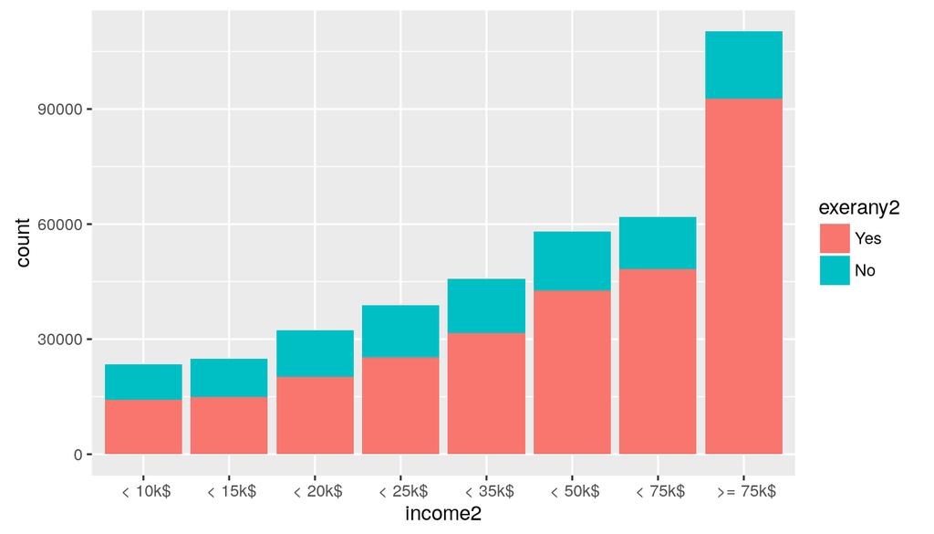

```r
brfss2013 %>% select(income2, exerany2) %>% filter(!is.na(income2), !is.na(exerany2)) -> income_exercises
ggplot(data = income_exercises, aes(x = income2, fill = exerany2)) + geom_bar() + scale_x_discrete(labels = c(" < 10k$", " < 15k$", " < 20k$", " < 25k$", " < 35k$", " < 50k$", " < 75k$", " >= 75k$"))
```

We can see that the higher they earn, the more they do exercises.

**Research quesion 2:** Does the Income Level has connection with Health Care Access.

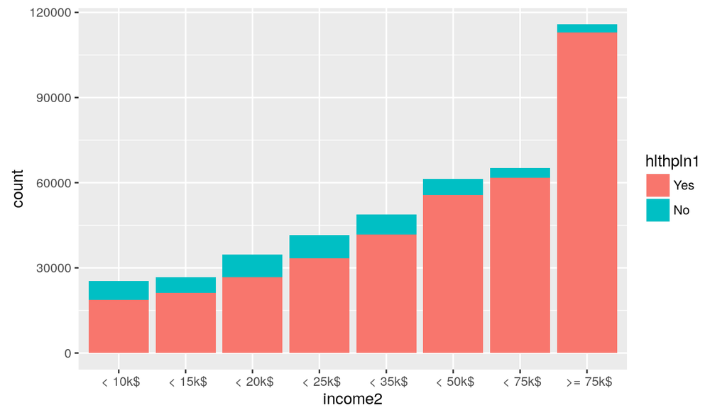

```r
brfss2013 %>% select(income2, hlthpln1) %>% filter(!is.na(income2), !is.na(hlthpln1)) -> income_healthcare
ggplot(data = income_healthcare, aes(x = income2, fill = hlthpln1)) + geom_bar() + scale_x_discrete(labels = c(" < 10k$", " < 15k$", " < 20k$", " < 25k$", " < 35k$", " < 50k$", " < 75k$", " >= 75k$"))
```

The more they earn, the more they have access to health care system.

**Research quesion 3:** Does the Income Level has connection with High Blood Pressure.

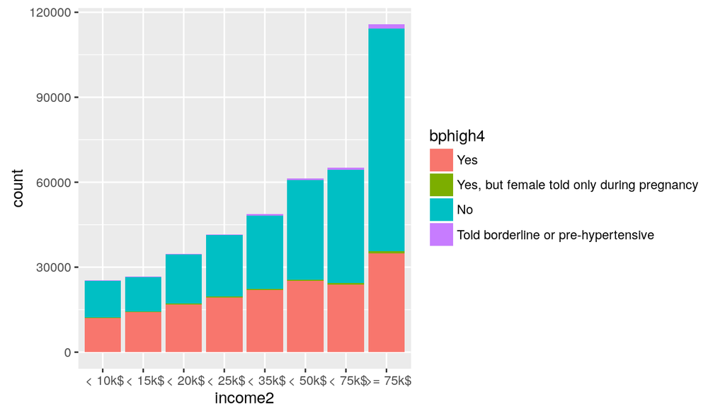

```r
brfss2013 %>% select(income2, bphigh4) %>% filter(!is.na(income2), !is.na(bphigh4)) -> income_pbhigh
ggplot(data = income_pbhigh, aes(x = income2, fill = bphigh4)) + geom_bar() + scale_x_discrete(labels = c(" < 10k$", " < 15k$", " < 20k$", " < 25k$", " < 35k$", " < 50k$", " < 75k$", " >= 75k$"))
```

The upper middle class and the richest has less cardiovascular diseases.